# dplyr and tidyr demonstration

Jan. 18th, 2015

## Introduction

This example shows an alternate way to generate the plot from Raphael Gottardo's RMarkdown presentation: Advanced_graphics_in_R.Rmd

The code presented here was written by Brian High, except for the `qplot` and `ggplot` plotting code, which was modified from Raphael Gottardo's original.

To the extent possible under law, Brian High has waived all copyright and related or neighboring rights to "dplyr and tidyr demonstration". This work is published from: United States.

## Load packages and data

Load ggplot2 and iris data.

```r
suppressMessages(library(ggplot2))
data(iris)
```

Load dplyr and tidyr.

```r
suppressMessages(library(dplyr))
suppressMessages(library(tidyr))
```

## dplyr: `mutate`

Using `mutate`, add a column to keep track of the flower id.

```r
iris_id <- mutate(iris, flower_id = rownames(iris))
head(iris_id)
```

```
##   Sepal.Length Sepal.Width Petal.Length Petal.Width Species flower_id
## 1          5.1         3.5          1.4         0.2  setosa         1
## 2          4.9         3.0          1.4         0.2  setosa         2
## 3          4.7         3.2          1.3         0.2  setosa         3
## 4          4.6         3.1          1.5         0.2  setosa         4
## 5          5.0         3.6          1.4         0.2  setosa         5
## 6          5.4         3.9          1.7         0.4  setosa         6
```

## tidyr: `gather`

Convert wide data format to long format.

```r
iris_gathered <- gather(iris_id, variable, value, c(-Species, -flower_id))
head(iris_gathered)
```

```
##   Species flower_id     variable value
## 1  setosa         1 Sepal.Length   5.1
## 2  setosa         2 Sepal.Length   4.9
## 3  setosa         3 Sepal.Length   4.7
## 4  setosa         4 Sepal.Length   4.6
## 5  setosa         5 Sepal.Length   5.0
## 6  setosa         6 Sepal.Length   5.4
```

## dplyr: `mutate` and `gsub`

Add new columns for the parsed values, remove the variable column.

```r
iris_parsed <- mutate(iris_gathered,
                      flower_part = gsub("(\\w*)\\.\\w*", "\\1", variable),
                      measurement_type = gsub("\\w*\\.(\\w*)", "\\1", variable),
                      variable = NULL)
head(iris_parsed)
```

```
##   Species flower_id value flower_part measurement_type
## 1  setosa         1   5.1       Sepal           Length
## 2  setosa         2   4.9       Sepal           Length
## 3  setosa         3   4.7       Sepal           Length
## 4  setosa         4   4.6       Sepal           Length
## 5  setosa         5   5.0       Sepal           Length
## 6  setosa         6   5.4       Sepal           Length
```

## tidyr: `extract`

You can also do the parsing and column creation with tidyr's `extract`.

```r
iris_parsed <- extract(iris_gathered, variable,
                       c("flower_part", "measurement_type"), "(.+)\\.(.+)")

head(iris_parsed)
```

```
##   Species flower_id flower_part measurement_type value
## 1  setosa         1       Sepal           Length   5.1
## 2  setosa         2       Sepal           Length   4.9
## 3  setosa         3       Sepal           Length   4.7
## 4  setosa         4       Sepal           Length   4.6
## 5  setosa         5       Sepal           Length   5.0
## 6  setosa         6       Sepal           Length   5.4
```

## tidyr: `spread`

Convert measurement_types to columns in wide format.

```r
iris_spread <- spread(iris_parsed, measurement_type, value)
head(iris_spread)
```

```
##   Species flower_id flower_part Length Width
## 1  setosa         1       Petal    1.4   0.2
## 2  setosa         1       Sepal    5.1   3.5
## 3  setosa        10       Petal    1.5   0.1
## 4  setosa        10       Sepal    4.9   3.1
## 5  setosa        11       Petal    1.5   0.2
## 6  setosa        11       Sepal    5.4   3.7
```

## Plot with ggplot2's `qplot`

Produce faceted plot with ggplot2's `qplot`.

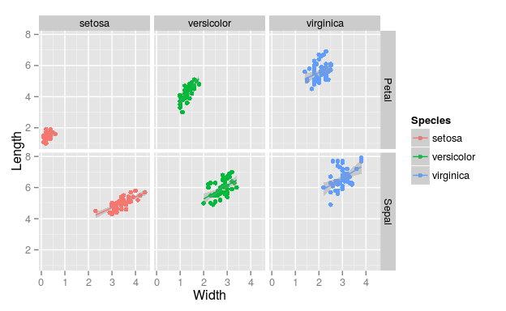

```r
qplot(x=Width, y=Length, data=iris_spread, geom=c("point","smooth"),
      color=Species, method="lm", facets= flower_part~Species)
```

## Repeat using a pipe

All of the data tidying could be done in one "pipe line".

```r
iris_spread <- mutate(iris, flower_id = rownames(iris)) %>%
    gather(variable, value, c(-Species, -flower_id)) %>%
    extract(variable, c("flower_part", "measurement_type"), "(.+)\\.(.+)") %>%
    spread(measurement_type, value)
```

## Plot with ggplot2's `qplot` again

Produce the faceted plot again with ggplot2's `qplot`.

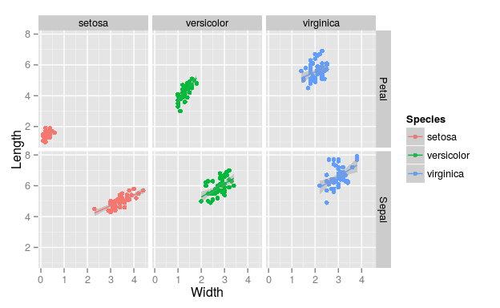

```r
qplot(x=Width, y=Length, data=iris_spread, geom=c("point","smooth"),
      color=Species, method="lm", facets= flower_part~Species)
```

## Plot with `ggplot`

Produce a faceted plot with ggplot2's `ggplot` instead of `qplot`.

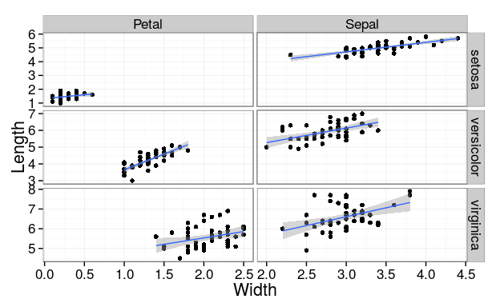

```r
ggplot(data=iris_spread, aes(x=Width, y=Length)) +
    geom_point() + facet_grid(Species~flower_part, scale="free") +
    geom_smooth(method="lm") + theme_bw(base_size=16)
```